# Flume Runs: 11/15/17 and 11/20/17

Justin Nghiem

11/16/17

*Source files* ⇒ LISST_floc2.Rmd ⇒ C:_values.rds

### Flume run on 11/15/17 (ambient conditions)

- sediment: none
- start collection: 11:45am
- end collection: 12:45am
- start flume: 11:55am
- frequency: 30 Hz
- flux: 216 US gal/min
- water depth: 45 cm
- slope: 0.00%

#### Notes:

- LISST positioned downstream of test section

The dataset has been processed to remove samples with optical transmission less than 0.1 or greater than 0.995. The plots of the densities use 6-minute time intervals (“groups”).

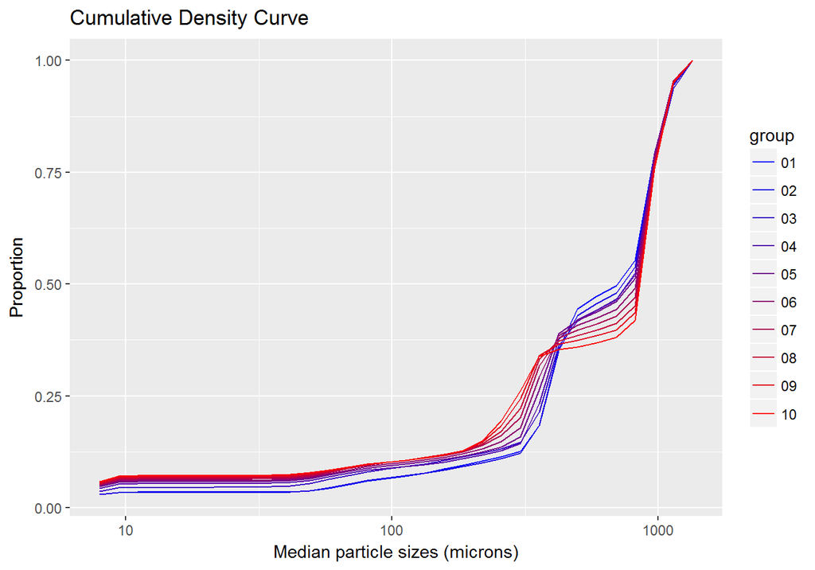

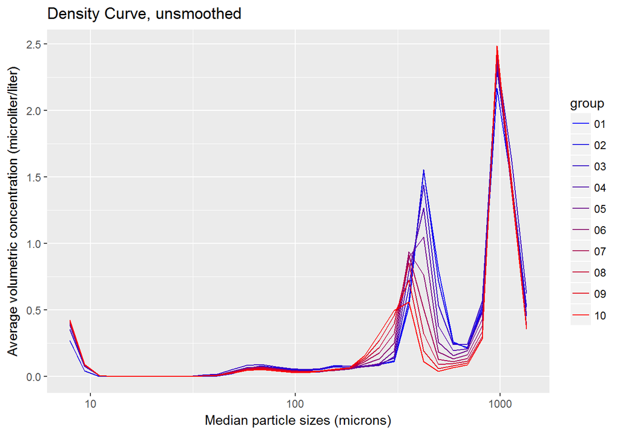

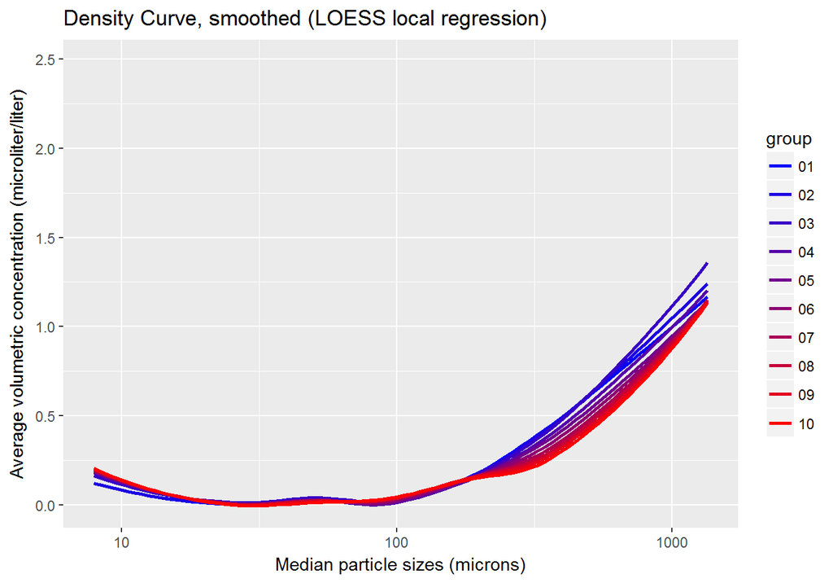

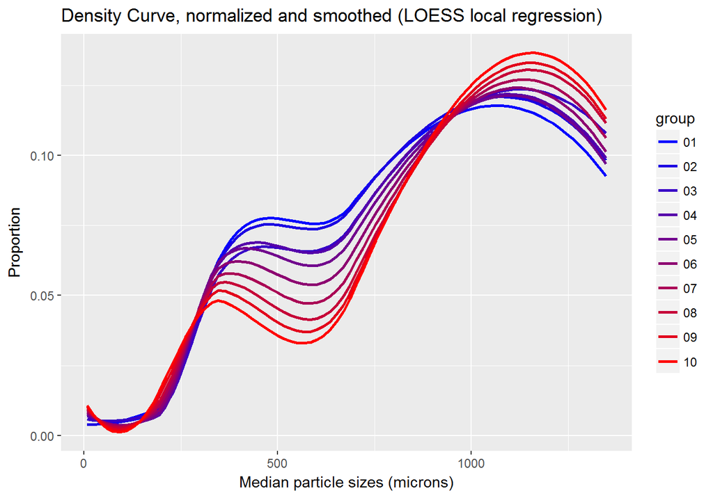

```
## [1] "Number of samples is 3596"
```

| group | avg_size |
| --- | --- |
| 1 | 725.2992 |
| 2 | 708.9740 |
| 3 | 708.8676 |
| 4 | 705.3872 |
| 5 | 706.2749 |
| 6 | 711.9482 |
| 7 | 705.1847 |
| 8 | 709.1868 |
| 9 | 713.7845 |
| 10 | 716.1278 |
| 11 | 713.6835 |
| 12 | 770.6061 |
| 13 | 754.9118 |
| 14 | 706.7580 |
| 15 | 715.6725 |
| 16 | 732.0521 |
| 17 | 706.6207 |
| 18 | 714.7730 |
| 19 | 726.1159 |
| 20 | 713.6927 |
| 21 | 712.1115 |
| 22 | 719.1624 |
| 23 | 712.0330 |
| 24 | 711.1403 |
| 25 | 711.7590 |
| 26 | 710.4007 |
| 27 | 708.3930 |
| 28 | 710.7829 |
| 29 | 711.9183 |
| 30 | 711.9063 |
| 31 | 712.7688 |
| 32 | 714.8479 |
| 33 | 716.3247 |
| 34 | 715.4788 |
| 35 | 717.1023 |
| 36 | 716.2877 |
| 37 | 716.7964 |
| 38 | 717.6044 |
| 39 | 718.6936 |
| 40 | 720.6596 |
| 41 | 723.6295 |
| 42 | 723.4618 |
| 43 | 724.4770 |
| 44 | 725.6417 |
| 45 | 727.5795 |
| 46 | 728.0398 |
| 47 | 727.2869 |
| 48 | 730.6264 |
| 49 | 728.6434 |
| 50 | 731.7134 |
| 51 | 730.6545 |
| 52 | 731.9011 |
| 53 | 732.6337 |
| 54 | 733.7418 |
| 55 | 737.5338 |
| 56 | 738.4007 |
| 57 | 740.4364 |
| 58 | 739.1106 |
| 59 | 740.6839 |
| 60 | 741.8863 |

`group` denotes the time interval. For example, `group` 1 is the time from the start of the experiment with a length of the time interval. `avg_size` is the mean particle size in microns. In the table above, time intervals are 1-minute. The plot of the table is:

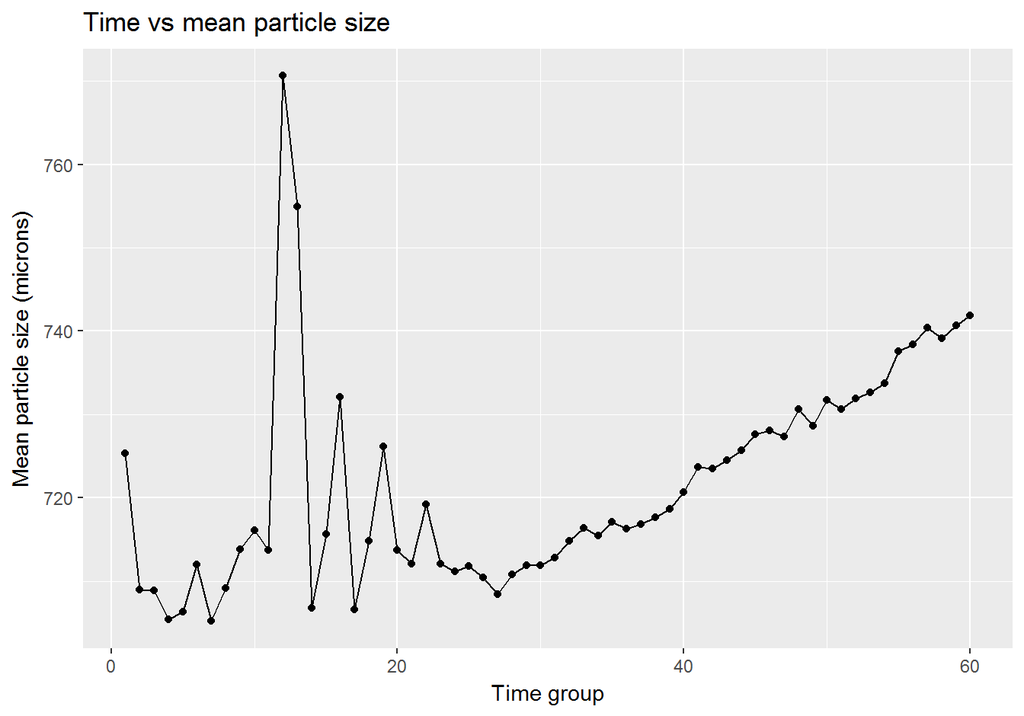

The `mean` of mean particle sizes is 721.5029189. The `standard deviation` of mean particle sizes is 12.9027233.

### Flume run on 11/15/17 (floc, high velocity)

- sediment: floc (kaolinite and NaCl)
- start collection: 1:00pm
- end collection: 4:00pm
- start flume: see notes
- frequency: 30 Hz
- flux: 215 US gal/min
- water depth: 47.54 cm
- slope: 0.00%

#### Notes

- LISST collected for ~2 minutes before the start of adding floc to the flume
- floc was completely added by 1:13pm
- water depth rose ~1 in from 45 cm in the process of adding floc in solution
- flume was left running from previous ambient run

The dataset has been processed to remove samples with optical transmission less than 0.1 or greater than 0.995. The plots of the densities use 10-minute time intervals (“groups”).

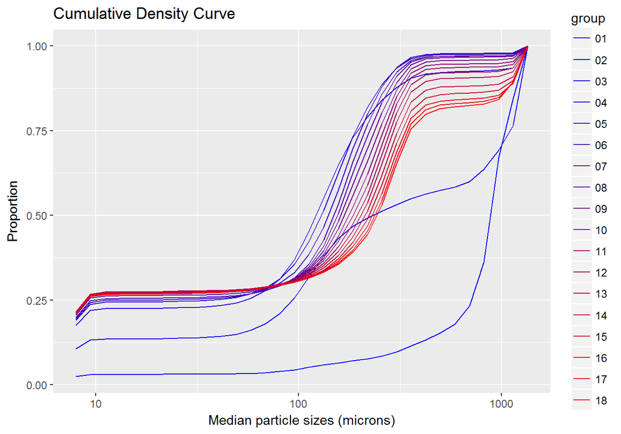

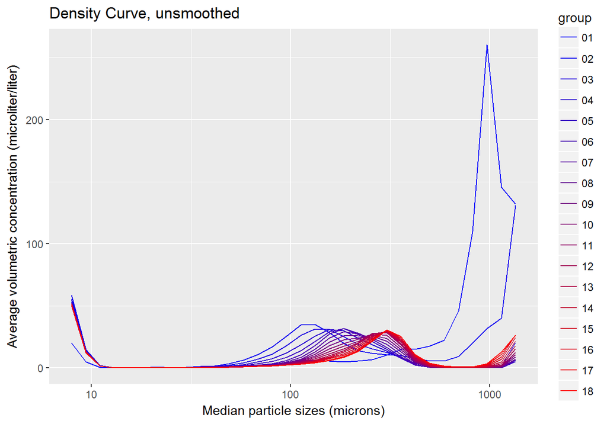

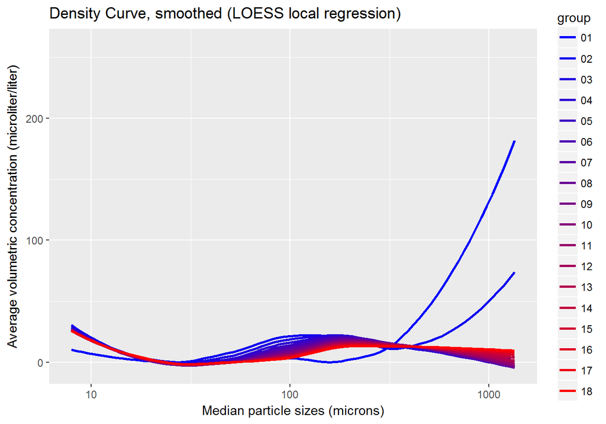

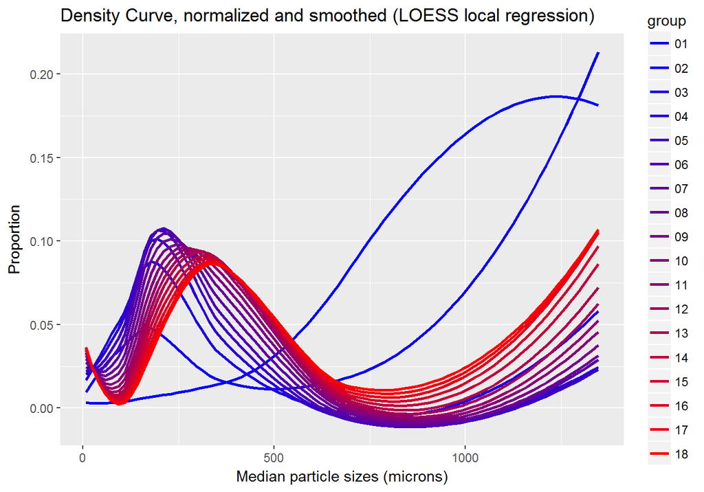

```
## [1] "Number of samples is 10426"
```

| group | avg_size |
| --- | --- |
| 1 | 737.6211 |
| 2 | 737.5280 |
| 3 | 893.8499 |
| 4 | 973.7816 |
| 5 | 989.5398 |
| 6 | 975.5205 |
| 7 | 766.3604 |
| 8 | 780.4021 |
| 9 | 809.1254 |
| 10 | 842.0113 |
| 11 | 588.2512 |
| 12 | 760.3422 |
| 13 | 665.9776 |
| 14 | 613.9069 |
| 15 | 717.0704 |
| 16 | 691.8751 |
| 17 | 521.6617 |
| 18 | 436.0705 |
| 19 | 383.5032 |
| 20 | 363.0993 |
| 21 | 316.5186 |
| 22 | 309.5025 |
| 23 | 275.2014 |
| 24 | 211.9402 |
| 25 | 187.1893 |
| 26 | 180.3761 |
| 27 | 164.9145 |
| 28 | 170.4573 |
| 29 | 172.4932 |
| 30 | 163.9590 |

[output cut: 150 more lines]

In the table above, time intervals are 1-minute. The plot of the table is:

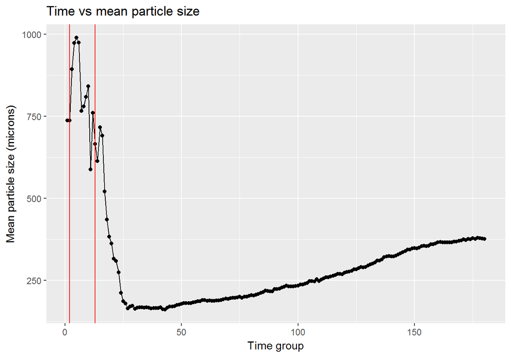

The red lines mark the time at which floc was being added.

### Combined time vs mean particle size

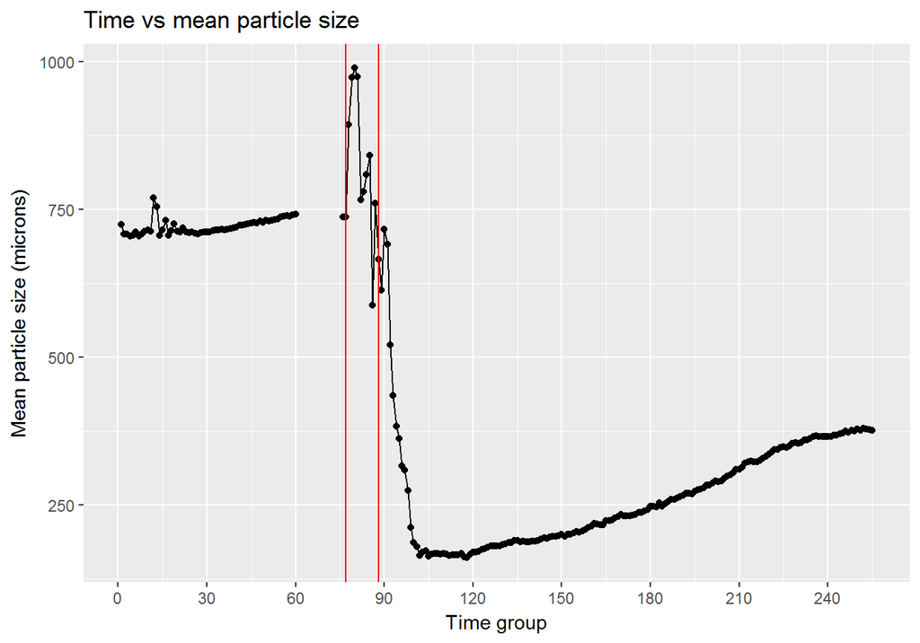

### Flume run on 11/20/17 (floc, low velocity)

- sediment: floc
- start collection: 10:35am
- end collection: 1:3pam
- start flume: 10:45am
- frequency: 10 Hz
- flux: 67.5 US gal/min
- water depth: 47.54 cm
- slope: 0.00%

#### Notes:

- LISST collected for 10 minutes at the start during which the flume was not turned on
- same water and floc as the 30 Hz run on 11/15/17

The dataset has been processed to remove samples with optical transmission less than 0.1 or greater than 0.995. The plots of the densities use 10-minute time intervals (“groups”).

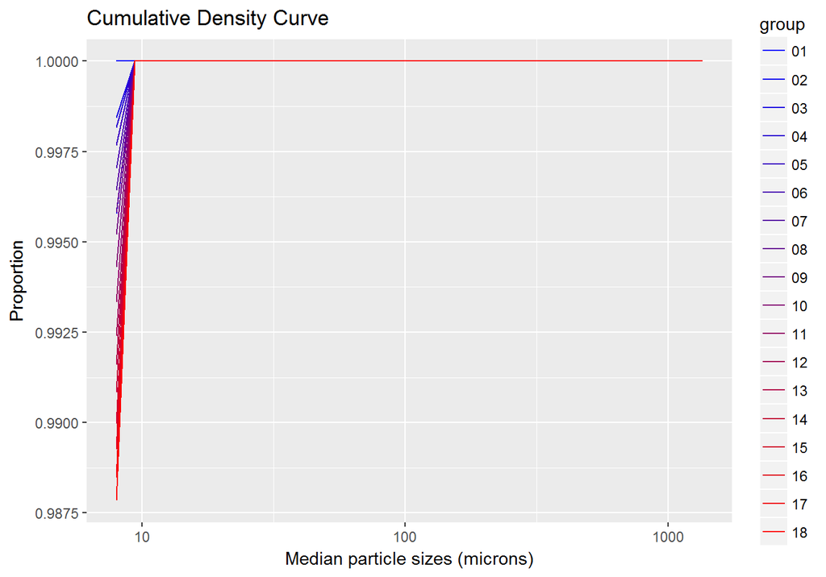

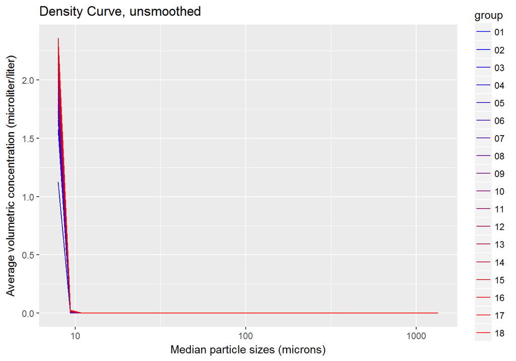

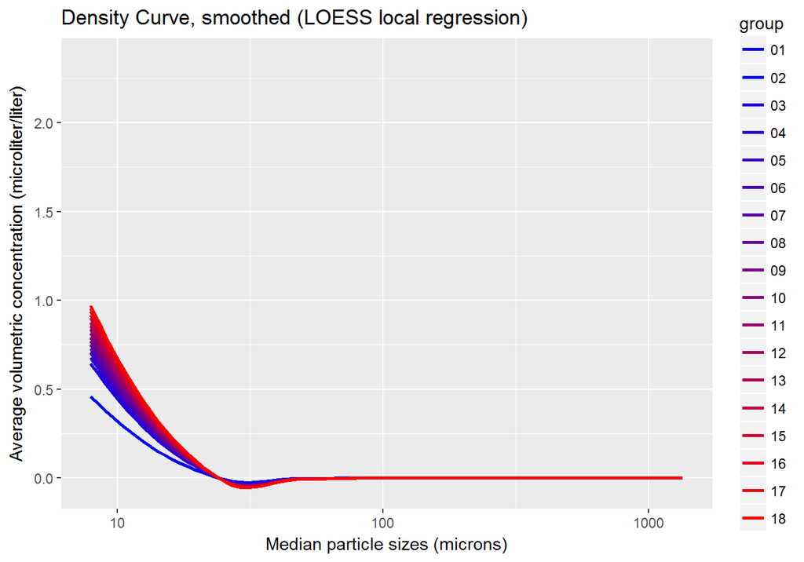

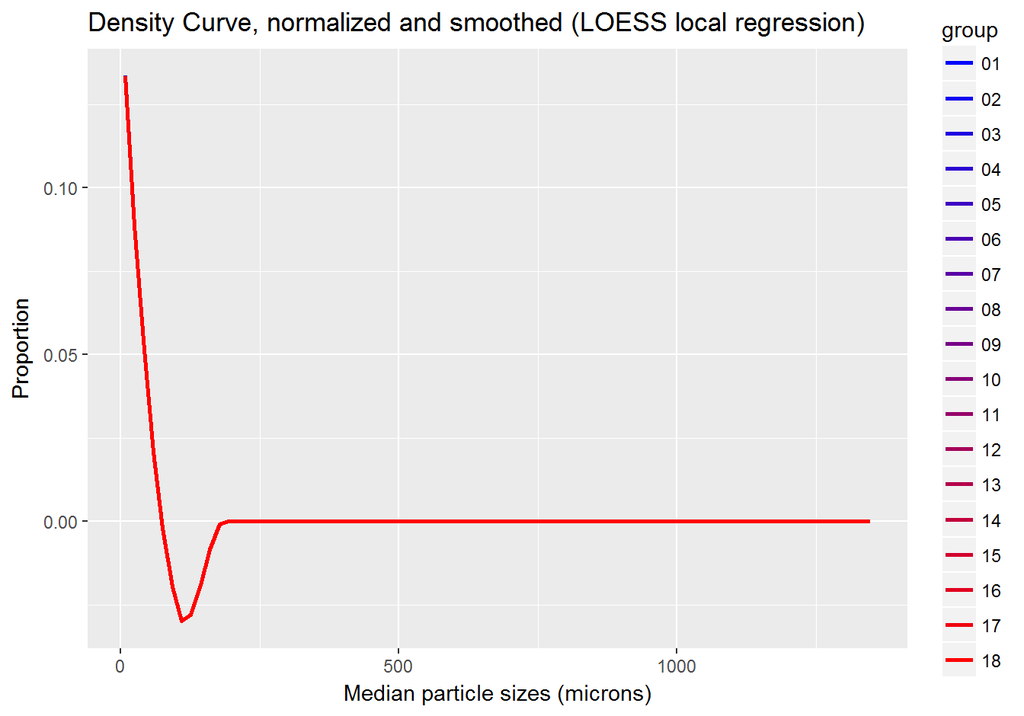

```
## [1] "Number of samples is 10802"
```

| group | avg_size |
| --- | --- |
| 1 | 7.950000 |
| 2 | 7.950000 |
| 3 | 7.950000 |
| 4 | 7.950000 |
| 5 | 7.950000 |
| 6 | 7.950000 |
| 7 | 7.950000 |
| 8 | 7.950000 |
| 9 | 7.950000 |
| 10 | 7.950000 |
| 11 | 7.950000 |
| 12 | 7.950000 |
| 13 | 7.950000 |
| 14 | 7.950000 |
| 15 | 7.950000 |
| 16 | 7.950000 |
| 17 | 7.955886 |
| 18 | 7.964547 |
| 19 | 7.959510 |
| 20 | 7.954735 |
| 21 | 7.952363 |
| 22 | 7.951057 |
| 23 | 7.950411 |
| 24 | 7.950166 |
| 25 | 7.950326 |
| 26 | 7.951722 |
| 27 | 7.952951 |
| 28 | 7.953631 |
| 29 | 7.953816 |
| 30 | 7.953024 |

[output cut: 150 more lines]

In the table above, time intervals are 1-minute. The plot of the table is:

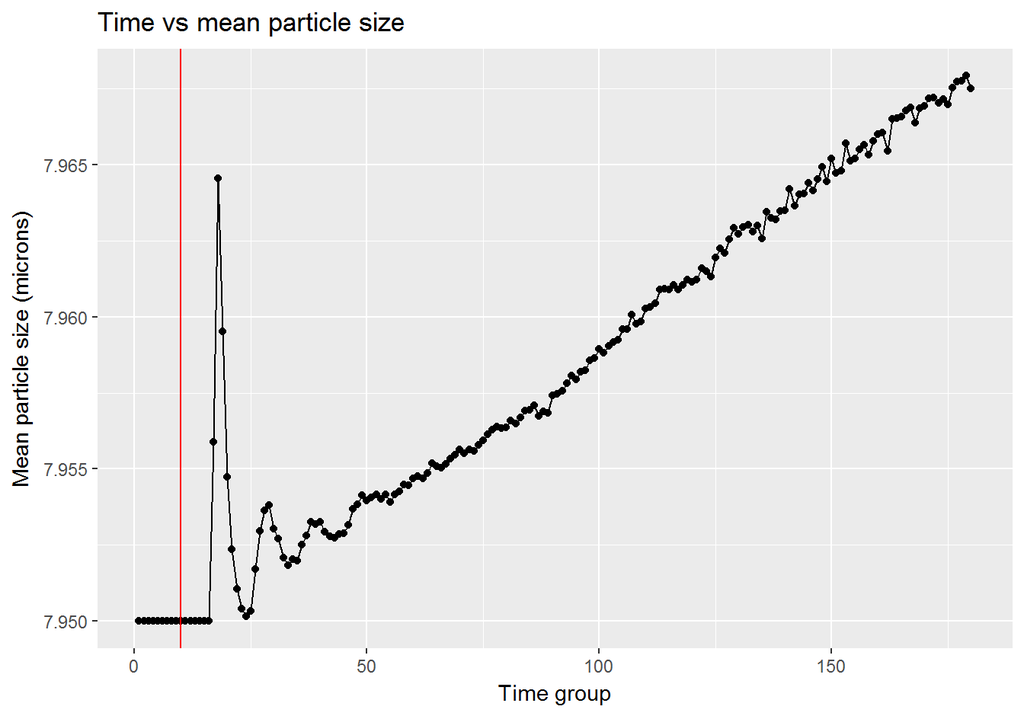

The red line marks the time at which flow began.